# Week 7 Tutorial

ECON90033 - 2023 Semester 2

Josh Copeland

Completed on 13 September 2023

## Exercise 3

```r
e3 <- read_excel("C:/Users/joshc/Documents/2023S2/ECON90033/Tutorials/Week 7/t7e3.xlsx", sheet = "URM")

ts_e3 <- function(x) {
  ts(x, start = c(1978,2), end = c(2023,1), frequency = 12)
}
```

### a) Plot URM and briefly describe the pattern of the data series

This tiem series has an additive seasonal component. Therefore, we should change the frequency from monthly to annual. Which has bene doing further below.

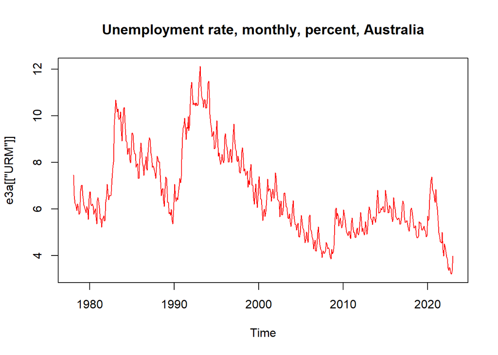

```r
e3a <- e3 %>%
  select(-Time) %>%
  map(~ts_e3(.x))


plot.ts(e3a[["URM"]], main = "Unemployment rate, monthly, percent, Australia", col = "red")
```

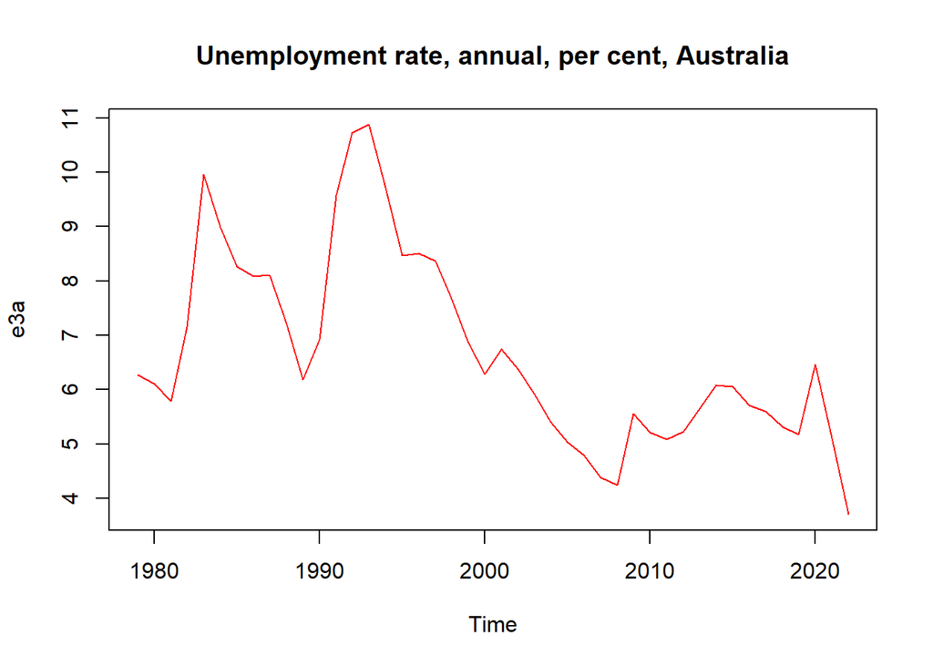

```r
library(tsbox)

e3a <- e3 %>%
  select(-Time) %>%
  ts(URM, frequency = 12, start = c(1978,2), end = c(2023,1)) %>%
  ts_frequency(to = "year", aggregate = "mean")


plot(e3a, main = "Unemployment rate, annual, per cent, Australia", col = "red")
```

We are only concerned with the first test statisic, -3.575. Because its between the 5% and 1% critical values, we reject the unit root null hypothesis. Note that because the critical values decrease as significance tests get smaller, rejection is to the left of them.

This test only used one lag of the differenced uenmployment rate in the ADF test regression. Since the residuals seem random, one lag is sufficent.

We’ve also done the same test for the first difference of the unemployment rate. The test statistic is -5.32, well below the 1% critical value. Therefore, we can reject the unit root null hypothesis at the 1% level.

Again, there is only 1 lag of the differenced unemployment rate, and because the residuals look random this is fine.

```r
library(urca)

e3b <- ur.df(e3a, type = "trend", selectlags = "BIC")

summary(e3b)
```

```
##
## ###############################################
## # Augmented Dickey-Fuller Test Unit Root Test #
## ###############################################
##
## Test regression trend
##
##
## Call:
## lm(formula = z.diff ~ z.lag.1 + 1 + tt + z.diff.lag)
##
## Residuals:
##      Min       1Q   Median       3Q      Max
## -1.67075 -0.49025  0.00632  0.38888  2.02883
##
## Coefficients:
##             Estimate Std. Error t value Pr(>|t|)
## (Intercept)  3.16336    0.87174   3.629 0.000835 ***
## z.lag.1     -0.34083    0.09534  -3.575 0.000974 ***
## tt          -0.03987    0.01309  -3.046 0.004197 **
## z.diff.lag   0.40280    0.14384   2.800 0.007982 **
## ---
## Signif. codes:  0 '***' 0.001 '**' 0.01 '*' 0.05 '.' 0.1 ' ' 1
##
## Residual standard error: 0.7987 on 38 degrees of freedom
## Multiple R-squared:  0.3196, Adjusted R-squared:  0.2659
## F-statistic: 5.951 on 3 and 38 DF,  p-value: 0.001977
##
##
## Value of test-statistic is: -3.575 4.676 6.9327
##
## Critical values for test statistics:
##       1pct  5pct 10pct
## tau3 -4.15 -3.50 -3.18
## phi2  7.02  5.13  4.31
## phi3  9.31  6.73  5.61
```

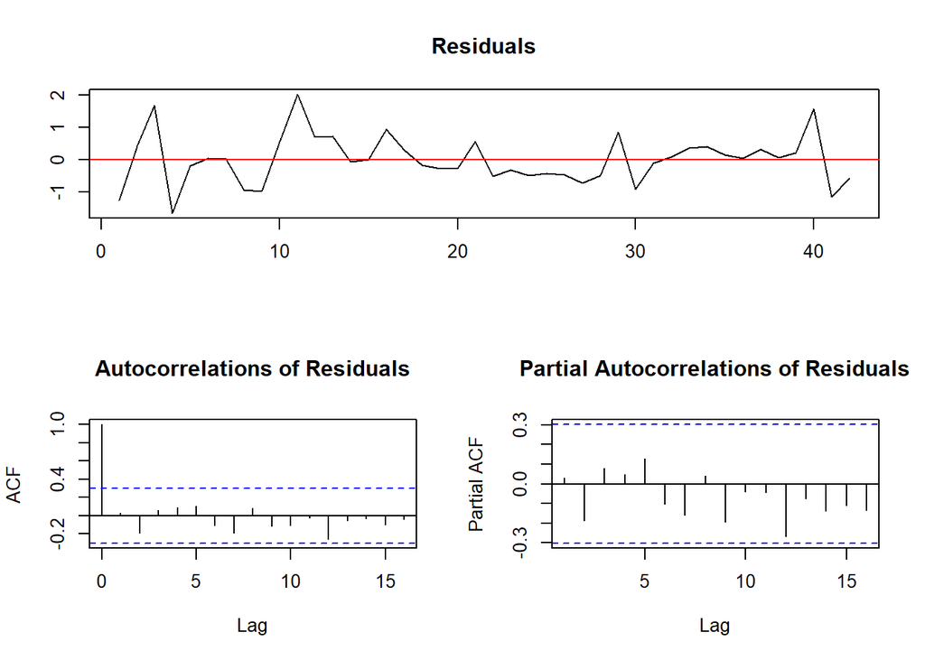

```r
plot(e3b)
```

```r
e3b_diff <- ur.df(diff(e3a), type = "drift", selectlags = "BIC")

summary(e3b_diff)
```

```
##
## ###############################################
## # Augmented Dickey-Fuller Test Unit Root Test #
## ###############################################
##
## Test regression drift
##
##
## Call:
## lm(formula = z.diff ~ z.lag.1 + 1 + z.diff.lag)
##
## Residuals:
##     Min      1Q  Median      3Q     Max
## -1.8290 -0.5732 -0.1374  0.3972  2.2285
##
## Coefficients:
##             Estimate Std. Error t value Pr(>|t|)
## (Intercept) -0.04022    0.13530  -0.297   0.7679
## z.lag.1     -1.02790    0.19299  -5.326 4.77e-06 ***
## z.diff.lag   0.38663    0.15722   2.459   0.0186 *
## ---
## Signif. codes:  0 '***' 0.001 '**' 0.01 '*' 0.05 '.' 0.1 ' ' 1
##
## Residual standard error: 0.866 on 38 degrees of freedom
## Multiple R-squared:  0.4395, Adjusted R-squared:   0.41
## F-statistic:  14.9 on 2 and 38 DF,  p-value: 1.67e-05
##
##
## Value of test-statistic is: -5.3262 14.2098
##
## Critical values for test statistics:
##       1pct  5pct 10pct
## tau2 -3.58 -2.93 -2.60
## phi1  7.06  4.86  3.94
```

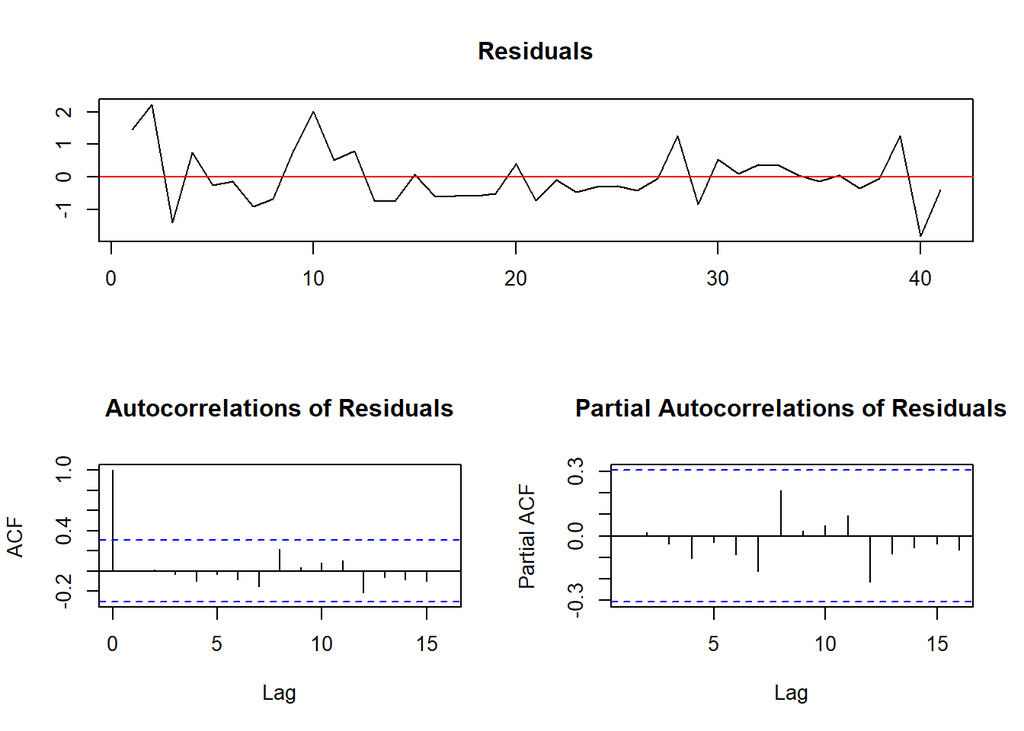

```r
plot(e3b_diff)
```

Now we’re going to same below the same process but using the KPSS test. Unlike the ADF test, rejection is to the right for the KPSS test.

However, the residuals do not seem random as they change sign relatively infrequently and seem to have positive first order autocorrelation. Therefore, we need to take the result of this test with caution.

Performing on the first difference we get the same result. Test statistic is 0.1394 and the 10% critical value is 0.347 - therefore we can maintain the null hypothesis even at the 10% level.

Looking at the residuals, there are 3 lags in the KPSS test regression, which seem to be sufficient even though SPACF has a significant spike at lag 2.

```r
e3b_kpss <- ur.kpss(e3a, type = "mu", lags = "short")

summary(e3b_kpss)
```

```
##
## #######################
## # KPSS Unit Root Test #
## #######################
##
## Test is of type: mu with 3 lags.
##
## Value of test-statistic is: 0.6796
##
## Critical value for a significance level of:
##                 10pct  5pct 2.5pct  1pct
## critical values 0.347 0.463  0.574 0.739
```

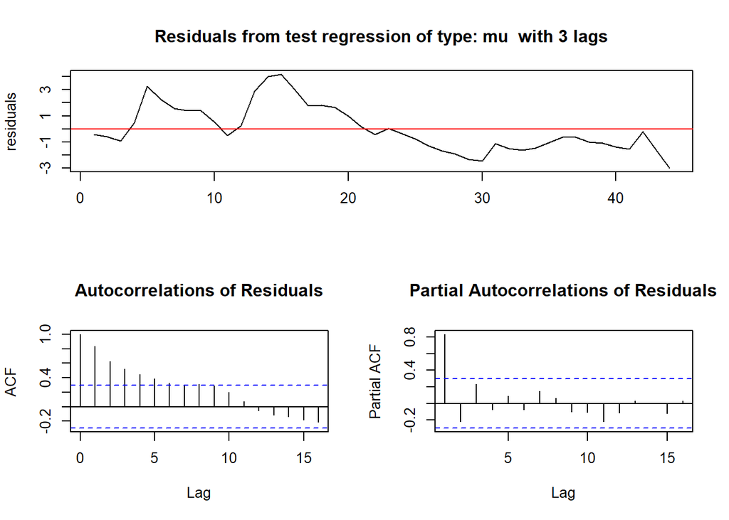

```r
plot(e3b_kpss)
```

```r
e3b_kpss_diff <- ur.kpss(diff(e3a), type = "mu", lags = "short")

summary(e3b_kpss_diff)
```

```
##
## #######################
## # KPSS Unit Root Test #
## #######################
##
## Test is of type: mu with 3 lags.
##
## Value of test-statistic is: 0.1394
##
## Critical value for a significance level of:
##                 10pct  5pct 2.5pct  1pct
## critical values 0.347 0.463  0.574 0.739
```

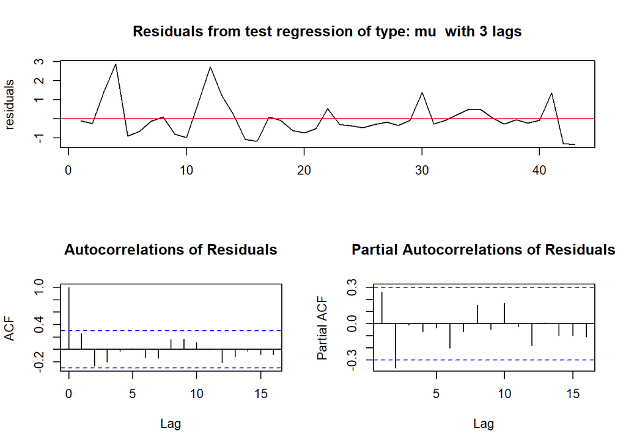

```r
plot(e3b_kpss_diff)
```

[figure not shown]

## c) Split the sample data into two parts, training data from 1979 to 2018 and test data from 2019 to 2022. Use the auto.arima() function of R and the AICC specification criterion to find the best fitting ARMA model for the unemployment rate over the training period.

What we’ve done here is generate the best fitting ARMA model and some other model to compare performance. According to the performance metrics:

- ARMA(1,1) produced more accurate ‘in-sample’ forecasts for the unemployment rate.
- But ME, MAE, MAPE, MASE favour the ARMA(2,0) model.

This might seem weird given ARMA(1,1) was chosen by the algorithm. However, this was only chosen because it chose the smallest AICC value, without consideration of any other metric. Model specification criteria, like AICC, serve different purposs other than forecast accuracy measures and thus may rank specifications differently.

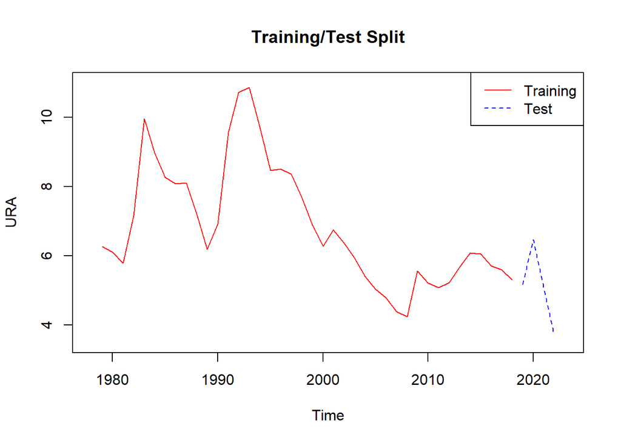

```r
e3c_train <- window(e3a, end = 2018)
e3c_test <- window(e3a, start = 2019)


plot(e3c_train, ylab = "URA", xlim = c(1978, 2023), ylim = c(3.5, 11),
col = "red", type = "l", main = "Training/Test Split")
lines(e3c_test, col = "blue", type = "l", lty = 2)
legend("topright", legend = c("Training", "Test"), col = c("red", "blue"), lty=1:2)
```

```r
t <- ts(1:length(e3c_train), start = 1979, frequency = 1)

library(forecast)

e3c_best_train <- auto.arima(e3c_train, seasonal = FALSE, xreg = t, ic = "aicc", approximation = FALSE, stepwise = FALSE, trace = TRUE)
```

```
##
##  Regression with ARIMA(0,0,0) errors : 237.5425
##  Regression with ARIMA(0,0,0) errors : 147.6699
##  Regression with ARIMA(0,0,1) errors : 194.3623
##  Regression with ARIMA(0,0,1) errors : 116.2753
##  Regression with ARIMA(0,0,2) errors : Inf
##  Regression with ARIMA(0,0,2) errors : 105.8326
##  Regression with ARIMA(0,0,3) errors : Inf
##  Regression with ARIMA(0,0,3) errors : 104.3388
##  Regression with ARIMA(0,0,4) errors : Inf
##  Regression with ARIMA(0,0,4) errors : 107.2741
##  Regression with ARIMA(0,0,5) errors : Inf
##  Regression with ARIMA(0,0,5) errors : 109.7446
##  Regression with ARIMA(1,0,0) errors : 113.6041
##  Regression with ARIMA(1,0,0) errors : 109.4485
##  Regression with ARIMA(1,0,1) errors : 108.6
##  Regression with ARIMA(1,0,1) errors : 102.1215
##  Regression with ARIMA(1,0,2) errors : 111.1017
##  Regression with ARIMA(1,0,2) errors : 104.2812
##  Regression with ARIMA(1,0,3) errors : Inf
##  Regression with ARIMA(1,0,3) errors : 107.2245
##  Regression with ARIMA(1,0,4) errors : Inf
##  Regression with ARIMA(1,0,4) errors : 110.2089
##  Regression with ARIMA(2,0,0) errors : 111.9557
##  Regression with ARIMA(2,0,0) errors : 103.2814
##  Regression with ARIMA(2,0,1) errors : 111.1765
##  Regression with ARIMA(2,0,1) errors : 104.3232
##  Regression with ARIMA(2,0,2) errors : Inf
##  Regression with ARIMA(2,0,2) errors : 107.23
##  Regression with ARIMA(2,0,3) errors : Inf
##  ARIMA(2,0,3) with non-zero mean : Inf
##  Regression with ARIMA(3,0,0) errors : 108.9074
##  Regression with ARIMA(3,0,0) errors : 104.446
##  Regression with ARIMA(3,0,1) errors : 111.6837
##  Regression with ARIMA(3,0,1) errors : 107.2177
##  Regression with ARIMA(3,0,2) errors : Inf
##  Regression with ARIMA(3,0,2) errors : Inf
##  Regression with ARIMA(4,0,0) errors : 111.6835
##  Regression with ARIMA(4,0,0) errors : 107.1084
##  Regression with ARIMA(4,0,1) errors : Inf
##  Regression with ARIMA(4,0,1) errors : 110.1577
##  Regression with ARIMA(5,0,0) errors : 114.6316
##  Regression with ARIMA(5,0,0) errors : 110.0308
##
##
##
##  Best model: Regression with ARIMA(1,0,1) errors
```

```r
summary(e3c_best_train)
```

```
## Series: e3c_train
## Regression with ARIMA(1,0,1) errors
##
## Coefficients:
##          ar1     ma1  intercept     xreg
##       0.6696  0.5536     8.1824  -0.0703
## s.e.  0.1275  0.1267     0.9859   0.0405
##
## sigma^2 = 0.5985:  log likelihood = -45.18
## AIC=100.36   AICc=102.12   BIC=108.8
##
## Training set error measures:
##                      ME      RMSE       MAE        MPE     MAPE     MASE
## Training set 0.03357786 0.7339103 0.5627155 -0.6280353 8.051542 0.900061
##                    ACF1
## Training set 0.04614642
```

```r
e3c_second <- Arima(e3c_train, order = c(2,0,0), xreg = t)
summary(e3c_second)
```

```
## Series: e3c_train
## Regression with ARIMA(2,0,0) errors
##
## Coefficients:
##          ar1      ar2  intercept     xreg
##       1.1640  -0.4534     8.4729  -0.0810
## s.e.  0.1378   0.1430     0.8095   0.0338
##
## sigma^2 = 0.6177:  log likelihood = -45.76
## AIC=101.52   AICc=103.28   BIC=109.96
##
## Training set error measures:
##                      ME      RMSE       MAE       MPE     MAPE     MASE
## Training set 0.01963738 0.7456095 0.5515288 -0.883973 7.957126 0.882168
##                    ACF1
## Training set 0.08082248
```

As always, it is always good practice to check the residuals of your models:

- For the “best” model the LB test shows residuals are serially uncorrelated. But based off the histogram and the SW test the residuals are not normally distributed.
- For the “second” model the LB test suggests the residuals are serially uncorrelated. Based on the histogram and SW test the residuals also appear to be normally distributed.

Therefore, the ARMA(2,0) model actually proved to be the more adequate.

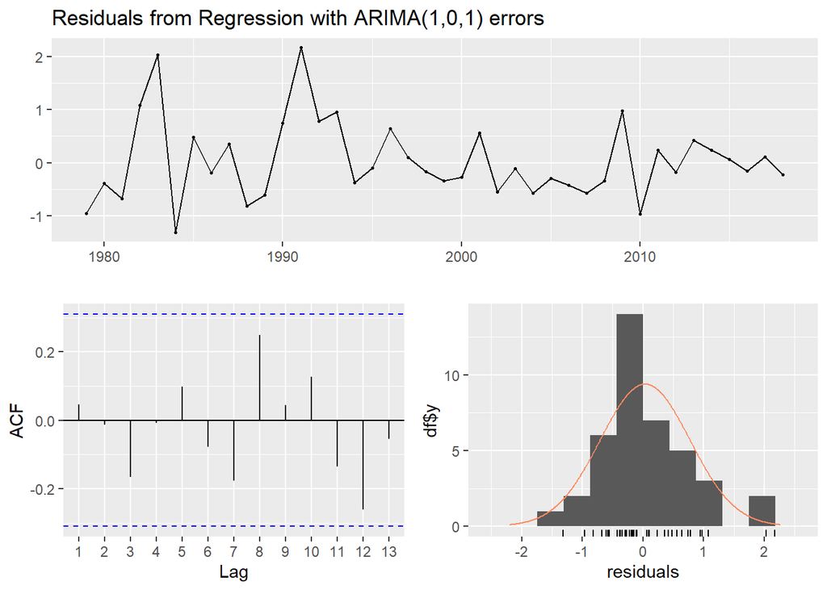

```
##
##  Ljung-Box test
##
## data:  Residuals from Regression with ARIMA(1,0,1) errors
## Q* = 6.9536, df = 6, p-value = 0.3252
##
## Model df: 2.   Total lags used: 8
```

```r
checkresiduals(e3c_best_train)
```

```r
shapiro.test(e3c_best_train$residuals)
```

```
##
##  Shapiro-Wilk normality test
##
## data:  e3c_best_train$residuals
## W = 0.93689, p-value = 0.02719
```

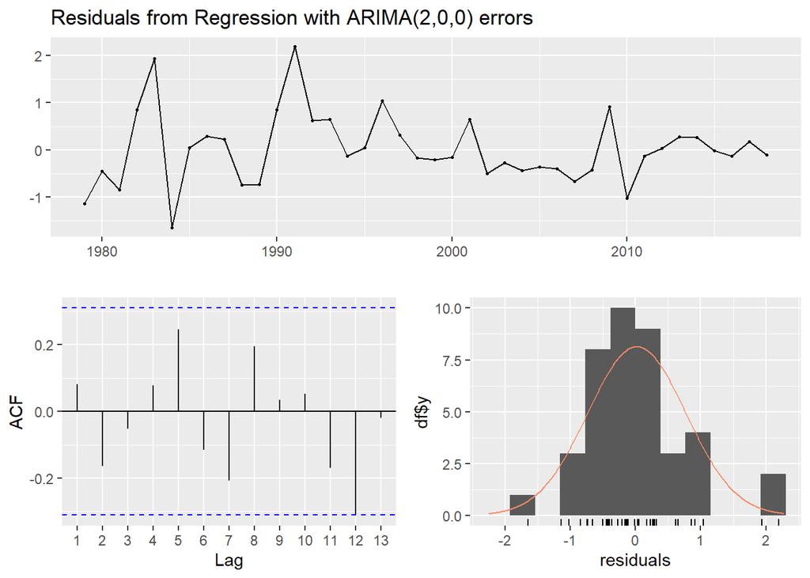

```
##
##  Ljung-Box test
##
## data:  Residuals from Regression with ARIMA(2,0,0) errors
## Q* = 9.6672, df = 6, p-value = 0.1394
##
## Model df: 2.   Total lags used: 8
```

```r
checkresiduals(e3c_second)
```

```r
shapiro.test(e3c_second$residuals)
```

```
##
##  Shapiro-Wilk normality test
##
## data:  e3c_second$residuals
## W = 0.95739, p-value = 0.1363
```

The code below forecasts the unemployment rate using the two models.

The accuracy function generates a host of forecast error metrics. It’s important you compare the model to the test data. These are the same metrics provided when generating the “summary” printout for each given model.

- According to ME, MAE, MAPE, MASE the ARMA(1,1) model produce the more accurate forecast.
- RMSE and MPE are in favour of the ARMA(2,0) model.

Therefore, we should expect ARMA(1,1) to generate more accurate ex ante forecasts.

Note that this is a different outcome to earlier, where we concluded that ARMA(2,0) produced better forecasts. This is because ARMA(2,0) produces better in-sample (ex-post) forecasts, but this exercise above shows ARMA(1,1) performs better out of sample.

```r
t = ts(1:length(e3a), start = 1979, frequency = 1)

ar1ma1_ftest <- forecast(e3c_best_train, xreg = window(t, start = 2019))

ar2ma0_ftest <- forecast(e3c_second, xreg = window(t, start = 2019))

print(ar2ma0_ftest)
```

```
##      Point Forecast    Lo 80    Hi 80    Lo 95    Hi 95
## 2019       5.110516 4.103292 6.117740 3.570099 6.650933
## 2020       4.988241 3.442590 6.533891 2.624372 7.352110
## 2021       4.911841 3.119194 6.704488 2.170224 7.653458
## 2022       4.854894 2.986827 6.722962 1.997932 7.711857
```

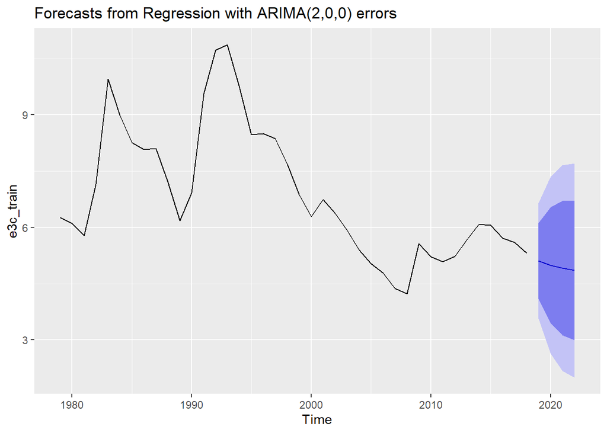

```r
autoplot(ar2ma0_ftest)
```

```r
print(ar1ma1_ftest)
```

```
##      Point Forecast    Lo 80    Hi 80    Lo 95    Hi 95
## 2019       5.133553 4.142133 6.124974 3.617307 6.649800
## 2020       5.118269 3.551952 6.684586 2.722793 7.513744
## 2021       5.084804 3.320561 6.849047 2.386628 7.782981
## 2022       5.039167 3.193069 6.885265 2.215804 7.862530
```

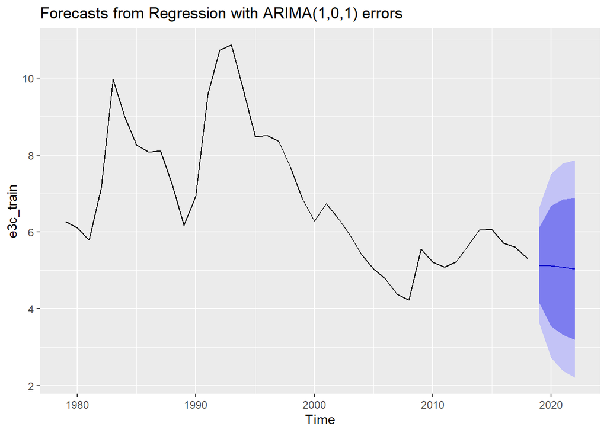

```r
autoplot(ar1ma1_ftest)
```

```r
accuracy(ar1ma1_ftest, e3c_test)
```

```
##                      ME      RMSE       MAE        MPE      MAPE     MASE
## Training set 0.03357786 0.7339103 0.5627155 -0.6280353  8.051542 0.900061
## Test set     0.01746977 0.9485569 0.6860592 -3.5259676 14.534312 1.097349
##                    ACF1 Theil's U
## Training set 0.04614642        NA
## Test set     0.00576534 0.8631515
```

```r
accuracy(ar2ma0_ftest, e3c_test)
```

```
##                      ME      RMSE       MAE        MPE      MAPE     MASE
## Training set 0.01963738 0.7456095 0.5515288 -0.8839730  7.957126 0.882168
## Test set     0.14504514 0.9419117 0.7214982 -0.8215184 14.749928 1.154033
##                     ACF1 Theil's U
## Training set  0.08082248        NA
## Test set     -0.03351969 0.8540419
```

### e) Forecast the unemployment rate for 2023-2026 with the ARMA(1,1) model

In part (c) we used auto.arima() to copmare specifications over the training period. Now that we’ve concluded ARMA(1,1) is the best performing model, it is time to re-estimate it from all available observations before generating the ex ante forecasts.

Re-estimating gives us a slightly different output. This is good, because a good modle shouldn’t change dramatically with the inclusion of a few new observations.

After estimating and forecasting we look at the residuals. The sample correlogram and LB test indicate the residuals are not autocorrelated and the histogram and the SW do not provide evidence against normality. Therefore, the stochastic errors might be serially uncorrelated and normally distributed.

```r
ar1ma1 <- Arima(e3a, c(1,0,1), xreg = t)

summary(ar1ma1)
```

```
## Series: e3a
## Regression with ARIMA(1,0,1) errors
##
## Coefficients:
##          ar1     ma1  intercept     xreg
##       0.6202  0.5613     8.3593  -0.0801
## s.e.  0.1363  0.1341     0.8762   0.0330
##
## sigma^2 = 0.6488:  log likelihood = -51.55
## AIC=113.1   AICc=114.68   BIC=122.02
##
## Training set error measures:
##                      ME      RMSE       MAE        MPE     MAPE      MASE
## Training set 0.03125849 0.7680081 0.5907548 -0.8533118 8.815547 0.8887828
##                    ACF1
## Training set 0.01704715
```

```r
t <- ts(1:(length(e3a) + 4), start = 1979, frequency = 1)

ar1ma1_eaf = forecast(ar1ma1, xreg = window(t,start = 2023))

print(ar1ma1_eaf)
```

```
##      Point Forecast    Lo 80    Hi 80    Lo 95    Hi 95
## 2023       3.812158 2.779877 4.844440 2.233420 5.390897
## 2024       4.089923 2.492106 5.687740 1.646272 6.533573
## 2025       4.231753 2.463963 5.999544 1.528151 6.935355
## 2026       4.289283 2.460322 6.118244 1.492128 7.086438
```

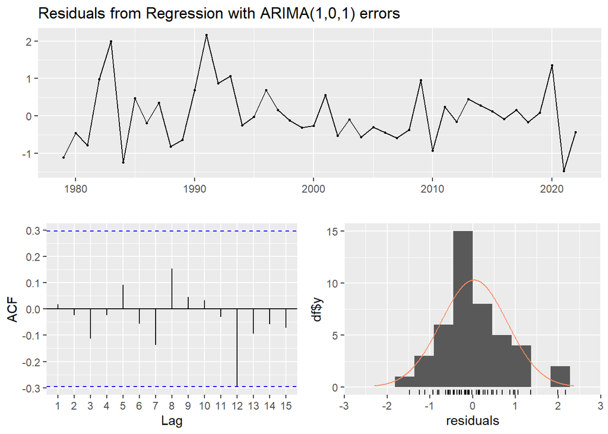

```
##
##  Ljung-Box test
##
## data:  Residuals from Regression with ARIMA(1,0,1) errors
## Q* = 3.7692, df = 7, p-value = 0.8059
##
## Model df: 2.   Total lags used: 9
```

```r
checkresiduals(ar1ma1)
```

```r
shapiro.test(ar1ma1$residuals)
```

```
##
##  Shapiro-Wilk normality test
##
## data:  ar1ma1$residuals
## W = 0.96546, p-value = 0.2075
```

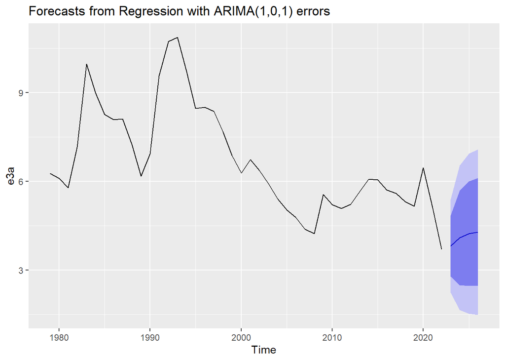

```r
autoplot(ar1ma1_eaf)
```